# AWS - assignment - Predictive Maintenance

```python
# Import train_test_split function
import pandas as pd
import numpy as np
from sklearn.model_selection import train_test_split
#Import Random Forest Model
from sklearn.ensemble import RandomForestClassifier
from sklearn.metrics import precision_score, recall_score, confusion_matrix, classification_report, accuracy_score, f1_score
from sklearn.model_selection import cross_val_predict, cross_val_score
from sklearn.decomposition import PCA
from sklearn.preprocessing import StandardScaler
from xgboost import XGBClassifier
from hyperopt import fmin, tpe, hp, STATUS_OK, Trials

from sklearn.base import BaseEstimator, TransformerMixin
from sklearn.pipeline import Pipeline, FeatureUnion
from sklearn.compose import ColumnTransformer

%matplotlib inline
import seaborn as sns
import matplotlib.pyplot as plt
import seaborn as sns

sns.set_style("darkgrid")

# import warnings filter to ignore all future warnings
from warnings import simplefilter
simplefilter(action='ignore', category=FutureWarning)
```

```python
#read telemetry data
df = pd.read_csv("/Users/md.kamal/Downloads/device_failure.csv", encoding = 'unicode_escape')
```

```python
df.head()
```

|  | date | device | failure | attribute1 | attribute2 | attribute3 | attribute4 | attribute5 | attribute6 | attribute7 | attribute8 | attribute9 |
| --- | --- | --- | --- | --- | --- | --- | --- | --- | --- | --- | --- | --- |
| 0 | 2015-01-01 | S1F01085 | 0 | 215630672 | 56 | 0 | 52 | 6 | 407438 | 0 | 0 | 7 |
| 1 | 2015-01-01 | S1F0166B | 0 | 61370680 | 0 | 3 | 0 | 6 | 403174 | 0 | 0 | 0 |
| 2 | 2015-01-01 | S1F01E6Y | 0 | 173295968 | 0 | 0 | 0 | 12 | 237394 | 0 | 0 | 0 |
| 3 | 2015-01-01 | S1F01JE0 | 0 | 79694024 | 0 | 0 | 0 | 6 | 410186 | 0 | 0 | 0 |
| 4 | 2015-01-01 | S1F01R2B | 0 | 135970480 | 0 | 0 | 0 | 15 | 313173 | 0 | 0 | 3 |

```python
df.describe()
```

|  | failure | attribute1 | attribute2 | attribute3 | attribute4 | attribute5 | attribute6 | attribute7 | attribute8 | attribute9 |
| --- | --- | --- | --- | --- | --- | --- | --- | --- | --- | --- |
| count | 124494.000000 | 1.244940e+05 | 124494.000000 | 124494.000000 | 124494.000000 | 124494.000000 | 124494.000000 | 124494.000000 | 124494.000000 | 124494.000000 |
| mean | 0.000851 | 1.223881e+08 | 159.484762 | 9.940455 | 1.741120 | 14.222669 | 260172.657726 | 0.292528 | 0.292528 | 12.451524 |
| std | 0.029167 | 7.045933e+07 | 2179.657730 | 185.747321 | 22.908507 | 15.943028 | 99151.078547 | 7.436924 | 7.436924 | 191.425623 |
| min | 0.000000 | 0.000000e+00 | 0.000000 | 0.000000 | 0.000000 | 1.000000 | 8.000000 | 0.000000 | 0.000000 | 0.000000 |
| 25% | 0.000000 | 6.128476e+07 | 0.000000 | 0.000000 | 0.000000 | 8.000000 | 221452.000000 | 0.000000 | 0.000000 | 0.000000 |
| 50% | 0.000000 | 1.227974e+08 | 0.000000 | 0.000000 | 0.000000 | 10.000000 | 249799.500000 | 0.000000 | 0.000000 | 0.000000 |
| 75% | 0.000000 | 1.833096e+08 | 0.000000 | 0.000000 | 0.000000 | 12.000000 | 310266.000000 | 0.000000 | 0.000000 | 0.000000 |
| max | 1.000000 | 2.441405e+08 | 64968.000000 | 24929.000000 | 1666.000000 | 98.000000 | 689161.000000 | 832.000000 | 832.000000 | 18701.000000 |

```python
df.groupby('failure')['failure'].count()
```

```
failure
0    124388
1       106
Name: failure, dtype: int64
```

```python
print('Distinct value count: \n')
for col in list(df):
    print(col, ":", len(df[col].unique()))
```

```
Distinct value count:

date : 304
device : 1169
failure : 2
attribute1 : 123877
attribute2 : 558
attribute3 : 47
attribute4 : 115
attribute5 : 60
attribute6 : 44838
attribute7 : 28
attribute8 : 28
attribute9 : 65
```

Overview

Dataset info

| Number of variables | 12 |
| --- | --- |
| Number of observations | 124494 |
| Total Missing (%) | 0.0% |
| Total size in memory | 11.4 MiB |
| Average record size in memory | 96.0 B |

Variables types

| Numeric | 8 |
| --- | --- |
| Categorical | 2 |
| Boolean | 1 |
| Date | 0 |
| Text (Unique) | 0 |
| Rejected | 1 |
| Unsupported | 0 |

Warnings

- `attribute2` has 118110 / 94.9% zeros Zeros

- `attribute2` is highly skewed (γ1 = 23.858) Skewed

- `attribute3` has 115359 / 92.7% zeros Zeros

- `attribute3` is highly skewed (γ1 = 82.712) Skewed

- `attribute4` has 115156 / 92.5% zeros Zeros

- `attribute4` is highly skewed (γ1 = 41.503) Skewed

- `attribute7` has 123036 / 98.8% zeros Zeros

- `attribute7` is highly skewed (γ1 = 73.476) Skewed

- `attribute8` is highly correlated with `attribute7` (ρ = 1) Rejected

- `attribute9` has 97358 / 78.2% zeros Zeros

- `attribute9` is highly skewed (γ1 = 49.899) Skewed

- `date` has a high cardinality: 304 distinct values Warning

- `device` has a high cardinality: 1169 distinct values Warning

- Dataset has 1 duplicate rows Warning

Variables

attribute1  
Numeric

| Distinct count | 123877 |
| --- | --- |
| Unique (%) | 99.5% |
| Missing (%) | 0.0% |
| Missing (n) | 0 |
| Infinite (%) | 0.0% |
| Infinite (n) | 0 |

| Mean | 122390000 |
| --- | --- |
| Minimum | 0 |
| Maximum | 244140480 |
| Zeros (%) | 0.0% |

Toggle details

**Statistics**

Quantile statistics

| Minimum | 0 |
| --- | --- |
| 5-th percentile | 12090000 |
| Q1 | 61285000 |
| Median | 122800000 |
| Q3 | 183310000 |
| 95-th percentile | 231870000 |
| Maximum | 244140480 |
| Range | 244140480 |
| Interquartile range | 122020000 |

Descriptive statistics

| Standard deviation | 70459000 |
| --- | --- |
| Coef of variation | 0.5757 |
| Kurtosis | -1.1993 |
| Mean | 122390000 |
| MAD | 61024000 |
| Skewness | -0.011143 |
| Sum | 15236584525025 |
| Variance | 4964500000000000 |
| Memory size | 972.7 KiB |

**Histogram**

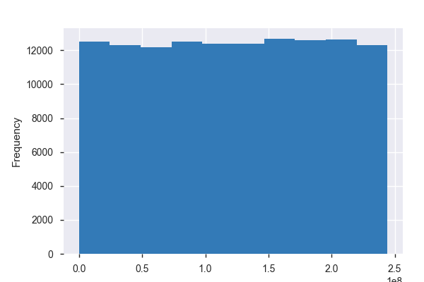

**Common Values**

| Value | Count | Frequency (%) |  |
| --- | --- | --- | --- |
| 89196552 | 26 | 0.0% |  |
| 165048912 | 26 | 0.0% |  |
| 57192360 | 26 | 0.0% |  |
| 169490248 | 23 | 0.0% |  |
| 57180136 | 15 | 0.0% |  |
| 169467344 | 15 | 0.0% |  |
| 12194976 | 15 | 0.0% |  |
| 165040624 | 15 | 0.0% |  |
| 89162648 | 15 | 0.0% |  |
| 165045144 | 13 | 0.0% |  |
| Other values (123867) | 124305 | 99.8% |  |

**Extreme Values**

Minimum 5 values

| Value | Count | Frequency (%) |  |
| --- | --- | --- | --- |
| 0 | 11 | 0.0% |  |
| 2048 | 1 | 0.0% |  |
| 2056 | 2 | 0.0% |  |
| 2168 | 1 | 0.0% |  |
| 3784 | 1 | 0.0% |  |

Maximum 5 values

| Value | Count | Frequency (%) |  |
| --- | --- | --- | --- |
| 244133240 | 1 | 0.0% |  |
| 244135688 | 1 | 0.0% |  |
| 244136552 | 1 | 0.0% |  |
| 244138600 | 1 | 0.0% |  |
| 244140480 | 1 | 0.0% |  |

attribute2  
Numeric

| Distinct count | 558 |
| --- | --- |
| Unique (%) | 0.4% |
| Missing (%) | 0.0% |
| Missing (n) | 0 |
| Infinite (%) | 0.0% |
| Infinite (n) | 0 |

| Mean | 159.48 |
| --- | --- |
| Minimum | 0 |
| Maximum | 64968 |
| Zeros (%) | 94.9% |

Toggle details

**Statistics**

Quantile statistics

| Minimum | 0 |
| --- | --- |
| 5-th percentile | 0 |
| Q1 | 0 |
| Median | 0 |
| Q3 | 0 |
| 95-th percentile | 8 |
| Maximum | 64968 |
| Range | 64968 |
| Interquartile range | 0 |

Descriptive statistics

| Standard deviation | 2179.7 |
| --- | --- |
| Coef of variation | 13.667 |
| Kurtosis | 626.82 |
| Mean | 159.48 |
| MAD | 305.82 |
| Skewness | 23.858 |
| Sum | 19854896 |
| Variance | 4750900 |
| Memory size | 972.7 KiB |

**Histogram**

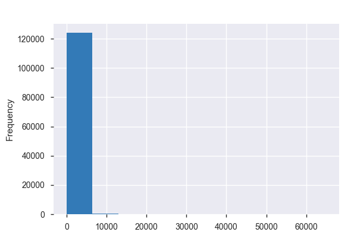

**Common Values**

| Value | Count | Frequency (%) |  |
| --- | --- | --- | --- |
| 0 | 118110 | 94.9% |  |
| 2344 | 281 | 0.2% |  |
| 8 | 260 | 0.2% |  |
| 24 | 254 | 0.2% |  |
| 40 | 201 | 0.2% |  |
| 4960 | 175 | 0.1% |  |
| 424 | 169 | 0.1% |  |
| 16 | 166 | 0.1% |  |
| 88 | 152 | 0.1% |  |
| 552 | 140 | 0.1% |  |
| Other values (548) | 4586 | 3.7% |  |

**Extreme Values**

Minimum 5 values

| Value | Count | Frequency (%) |  |
| --- | --- | --- | --- |
| 0 | 118110 | 94.9% |  |
| 8 | 260 | 0.2% |  |
| 16 | 166 | 0.1% |  |
| 24 | 254 | 0.2% |  |
| 32 | 132 | 0.1% |  |

Maximum 5 values

| Value | Count | Frequency (%) |  |
| --- | --- | --- | --- |
| 64736 | 13 | 0.0% |  |
| 64776 | 8 | 0.0% |  |
| 64784 | 11 | 0.0% |  |
| 64792 | 7 | 0.0% |  |
| 64968 | 1 | 0.0% |  |

attribute3  
Numeric

| Distinct count | 47 |
| --- | --- |
| Unique (%) | 0.0% |
| Missing (%) | 0.0% |
| Missing (n) | 0 |
| Infinite (%) | 0.0% |
| Infinite (n) | 0 |

| Mean | 9.9405 |
| --- | --- |
| Minimum | 0 |
| Maximum | 24929 |
| Zeros (%) | 92.7% |

Toggle details

**Statistics**

Quantile statistics

| Minimum | 0 |
| --- | --- |
| 5-th percentile | 0 |
| Q1 | 0 |
| Median | 0 |
| Q3 | 0 |
| 95-th percentile | 1 |
| Maximum | 24929 |
| Range | 24929 |
| Interquartile range | 0 |

Descriptive statistics

| Standard deviation | 185.75 |
| --- | --- |
| Coef of variation | 18.686 |
| Kurtosis | 10474 |
| Mean | 9.9405 |
| MAD | 19.074 |
| Skewness | 82.712 |
| Sum | 1237527 |
| Variance | 34502 |
| Memory size | 972.7 KiB |

**Histogram**

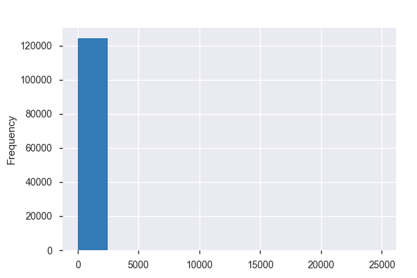

**Common Values**

| Value | Count | Frequency (%) |  |
| --- | --- | --- | --- |
| 0 | 115359 | 92.7% |  |
| 1 | 3274 | 2.6% |  |
| 2 | 749 | 0.6% |  |
| 7 | 298 | 0.2% |  |
| 34 | 293 | 0.2% |  |
| 5 | 278 | 0.2% |  |
| 21 | 269 | 0.2% |  |
| 4 | 268 | 0.2% |  |
| 9 | 262 | 0.2% |  |
| 8 | 251 | 0.2% |  |
| Other values (37) | 3193 | 2.6% |  |

**Extreme Values**

Minimum 5 values

| Value | Count | Frequency (%) |  |
| --- | --- | --- | --- |
| 0 | 115359 | 92.7% |  |
| 1 | 3274 | 2.6% |  |
| 2 | 749 | 0.6% |  |
| 3 | 113 | 0.1% |  |
| 4 | 268 | 0.2% |  |

Maximum 5 values

| Value | Count | Frequency (%) |  |
| --- | --- | --- | --- |
| 1326 | 5 | 0.0% |  |
| 1331 | 240 | 0.2% |  |
| 2112 | 6 | 0.0% |  |
| 2693 | 179 | 0.1% |  |
| 24929 | 4 | 0.0% |  |

attribute4  
Numeric

| Distinct count | 115 |
| --- | --- |
| Unique (%) | 0.1% |
| Missing (%) | 0.0% |
| Missing (n) | 0 |
| Infinite (%) | 0.0% |
| Infinite (n) | 0 |

| Mean | 1.7411 |
| --- | --- |
| Minimum | 0 |
| Maximum | 1666 |
| Zeros (%) | 92.5% |

Toggle details

**Statistics**

Quantile statistics

| Minimum | 0 |
| --- | --- |
| 5-th percentile | 0 |
| Q1 | 0 |
| Median | 0 |
| Q3 | 0 |
| 95-th percentile | 6 |
| Maximum | 1666 |
| Range | 1666 |
| Interquartile range | 0 |

Descriptive statistics

| Standard deviation | 22.909 |
| --- | --- |
| Coef of variation | 13.157 |
| Kurtosis | 2468 |
| Mean | 1.7411 |
| MAD | 3.2316 |
| Skewness | 41.503 |
| Sum | 216759 |
| Variance | 524.8 |
| Memory size | 972.7 KiB |

**Histogram**

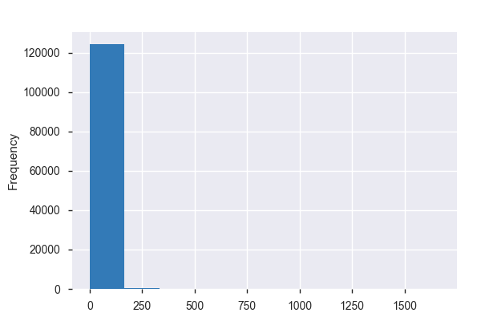

**Common Values**

| Value | Count | Frequency (%) |  |
| --- | --- | --- | --- |
| 0 | 115156 | 92.5% |  |
| 6 | 3681 | 3.0% |  |
| 1 | 889 | 0.7% |  |
| 2 | 711 | 0.6% |  |
| 3 | 466 | 0.4% |  |
| 12 | 454 | 0.4% |  |
| 4 | 359 | 0.3% |  |
| 10 | 294 | 0.2% |  |
| 112 | 245 | 0.2% |  |
| 5 | 231 | 0.2% |  |
| Other values (105) | 2008 | 1.6% |  |

**Extreme Values**

Minimum 5 values

| Value | Count | Frequency (%) |  |
| --- | --- | --- | --- |
| 0 | 115156 | 92.5% |  |
| 1 | 889 | 0.7% |  |
| 2 | 711 | 0.6% |  |
| 3 | 466 | 0.4% |  |
| 4 | 359 | 0.3% |  |

Maximum 5 values

| Value | Count | Frequency (%) |  |
| --- | --- | --- | --- |
| 763 | 1 | 0.0% |  |
| 841 | 1 | 0.0% |  |
| 1033 | 3 | 0.0% |  |
| 1074 | 6 | 0.0% |  |
| 1666 | 9 | 0.0% |  |

attribute5  
Numeric

| Distinct count | 60 |
| --- | --- |
| Unique (%) | 0.0% |
| Missing (%) | 0.0% |
| Missing (n) | 0 |
| Infinite (%) | 0.0% |
| Infinite (n) | 0 |

| Mean | 14.223 |
| --- | --- |
| Minimum | 1 |
| Maximum | 98 |
| Zeros (%) | 0.0% |

Toggle details

**Statistics**

Quantile statistics

| Minimum | 1 |
| --- | --- |
| 5-th percentile | 6 |
| Q1 | 8 |
| Median | 10 |
| Q3 | 12 |
| 95-th percentile | 58 |
| Maximum | 98 |
| Range | 97 |
| Interquartile range | 4 |

Descriptive statistics

| Standard deviation | 15.943 |
| --- | --- |
| Coef of variation | 1.121 |
| Kurtosis | 12.152 |
| Mean | 14.223 |
| MAD | 8.5987 |
| Skewness | 3.4837 |
| Sum | 1770637 |
| Variance | 254.18 |
| Memory size | 972.7 KiB |

**Histogram**

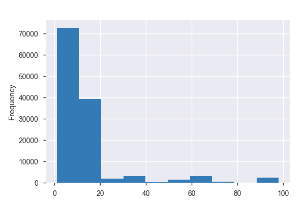

**Common Values**

| Value | Count | Frequency (%) |  |
| --- | --- | --- | --- |
| 8 | 22145 | 17.8% |  |
| 9 | 13597 | 10.9% |  |
| 11 | 12792 | 10.3% |  |
| 10 | 11480 | 9.2% |  |
| 7 | 11271 | 9.1% |  |
| 12 | 9843 | 7.9% |  |
| 6 | 8542 | 6.9% |  |
| 13 | 6006 | 4.8% |  |
| 14 | 3517 | 2.8% |  |
| 5 | 3429 | 2.8% |  |
| Other values (50) | 21872 | 17.6% |  |

**Extreme Values**

Minimum 5 values

| Value | Count | Frequency (%) |  |
| --- | --- | --- | --- |
| 1 | 173 | 0.1% |  |
| 2 | 203 | 0.2% |  |
| 3 | 815 | 0.7% |  |
| 4 | 933 | 0.7% |  |
| 5 | 3429 | 2.8% |  |

Maximum 5 values

| Value | Count | Frequency (%) |  |
| --- | --- | --- | --- |
| 91 | 215 | 0.2% |  |
| 92 | 448 | 0.4% |  |
| 94 | 224 | 0.2% |  |
| 95 | 672 | 0.5% |  |
| 98 | 224 | 0.2% |  |

attribute6  
Numeric

| Distinct count | 44838 |
| --- | --- |
| Unique (%) | 36.0% |
| Missing (%) | 0.0% |
| Missing (n) | 0 |
| Infinite (%) | 0.0% |
| Infinite (n) | 0 |

| Mean | 260170 |
| --- | --- |
| Minimum | 8 |
| Maximum | 689161 |
| Zeros (%) | 0.0% |

Toggle details

**Statistics**

Quantile statistics

| Minimum | 8 |
| --- | --- |
| 5-th percentile | 46 |
| Q1 | 221450 |
| Median | 249800 |
| Q3 | 310270 |
| 95-th percentile | 443050 |
| Maximum | 689161 |
| Range | 689153 |
| Interquartile range | 88814 |

Descriptive statistics

| Standard deviation | 99151 |
| --- | --- |
| Coef of variation | 0.3811 |
| Kurtosis | 1.9078 |
| Mean | 260170 |
| MAD | 66945 |
| Skewness | -0.37528 |
| Sum | 32389934851 |
| Variance | 9830900000 |
| Memory size | 972.7 KiB |

**Histogram**

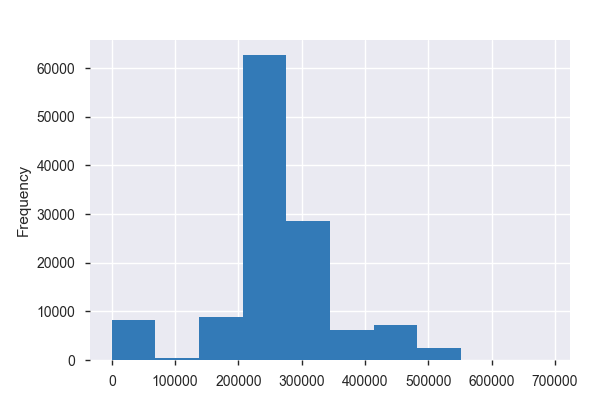

**Common Values**

| Value | Count | Frequency (%) |  |
| --- | --- | --- | --- |
| 31 | 777 | 0.6% |  |
| 44 | 708 | 0.6% |  |
| 27 | 636 | 0.5% |  |
| 26 | 520 | 0.4% |  |
| 29 | 441 | 0.4% |  |
| 36 | 337 | 0.3% |  |
| 35 | 290 | 0.2% |  |
| 52 | 282 | 0.2% |  |
| 45 | 246 | 0.2% |  |
| 28 | 216 | 0.2% |  |
| Other values (44828) | 120041 | 96.4% |  |

**Extreme Values**

Minimum 5 values

| Value | Count | Frequency (%) |  |
| --- | --- | --- | --- |
| 8 | 19 | 0.0% |  |
| 9 | 172 | 0.1% |  |
| 12 | 51 | 0.0% |  |
| 18 | 36 | 0.0% |  |
| 19 | 30 | 0.0% |  |

Maximum 5 values

| Value | Count | Frequency (%) |  |
| --- | --- | --- | --- |
| 688952 | 2 | 0.0% |  |
| 688964 | 1 | 0.0% |  |
| 689035 | 1 | 0.0% |  |
| 689062 | 1 | 0.0% |  |
| 689161 | 1 | 0.0% |  |

attribute7  
Numeric

| Distinct count | 28 |
| --- | --- |
| Unique (%) | 0.0% |
| Missing (%) | 0.0% |
| Missing (n) | 0 |
| Infinite (%) | 0.0% |
| Infinite (n) | 0 |

| Mean | 0.29253 |
| --- | --- |
| Minimum | 0 |
| Maximum | 832 |
| Zeros (%) | 98.8% |

Toggle details

**Statistics**

Quantile statistics

| Minimum | 0 |
| --- | --- |
| 5-th percentile | 0 |
| Q1 | 0 |
| Median | 0 |
| Q3 | 0 |
| 95-th percentile | 0 |
| Maximum | 832 |
| Range | 832 |
| Interquartile range | 0 |

Descriptive statistics

| Standard deviation | 7.4369 |
| --- | --- |
| Coef of variation | 25.423 |
| Kurtosis | 6876.3 |
| Mean | 0.29253 |
| MAD | 0.5782 |
| Skewness | 73.476 |
| Sum | 36418 |
| Variance | 55.308 |
| Memory size | 972.7 KiB |

**Histogram**

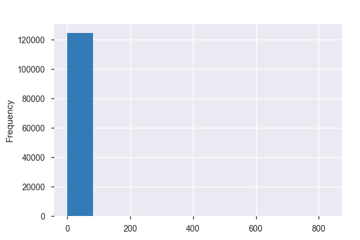

**Common Values**

| Value | Count | Frequency (%) |  |
| --- | --- | --- | --- |
| 0 | 123036 | 98.8% |  |
| 8 | 793 | 0.6% |  |
| 16 | 397 | 0.3% |  |
| 24 | 65 | 0.1% |  |
| 48 | 36 | 0.0% |  |
| 32 | 35 | 0.0% |  |
| 128 | 23 | 0.0% |  |
| 176 | 20 | 0.0% |  |
| 40 | 20 | 0.0% |  |
| 6 | 13 | 0.0% |  |
| Other values (18) | 56 | 0.0% |  |

**Extreme Values**

Minimum 5 values

| Value | Count | Frequency (%) |  |
| --- | --- | --- | --- |
| 0 | 123036 | 98.8% |  |
| 6 | 13 | 0.0% |  |
| 8 | 793 | 0.6% |  |
| 16 | 397 | 0.3% |  |
| 22 | 2 | 0.0% |  |

Maximum 5 values

| Value | Count | Frequency (%) |  |
| --- | --- | --- | --- |
| 424 | 1 | 0.0% |  |
| 496 | 1 | 0.0% |  |
| 736 | 4 | 0.0% |  |
| 744 | 1 | 0.0% |  |
| 832 | 2 | 0.0% |  |

attribute8  
Highly correlated

*This variable is highly correlated with `attribute7` and should be ignored for analysis*

| Correlation | 1 |
| --- | --- |

attribute9  
Numeric

| Distinct count | 65 |
| --- | --- |
| Unique (%) | 0.1% |
| Missing (%) | 0.0% |
| Missing (n) | 0 |
| Infinite (%) | 0.0% |
| Infinite (n) | 0 |

| Mean | 12.452 |
| --- | --- |
| Minimum | 0 |
| Maximum | 18701 |
| Zeros (%) | 78.2% |

Toggle details

**Statistics**

Quantile statistics

| Minimum | 0 |
| --- | --- |
| 5-th percentile | 0 |
| Q1 | 0 |
| Median | 0 |
| Q3 | 0 |
| 95-th percentile | 11 |
| Maximum | 18701 |
| Range | 18701 |
| Interquartile range | 0 |

Descriptive statistics

| Standard deviation | 191.43 |
| --- | --- |
| Coef of variation | 15.374 |
| Kurtosis | 4050.2 |
| Mean | 12.452 |
| MAD | 22.718 |
| Skewness | 49.899 |
| Sum | 1550140 |
| Variance | 36644 |
| Memory size | 972.7 KiB |

**Histogram**

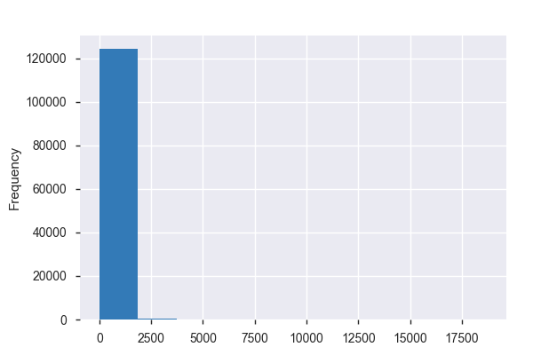

**Common Values**

| Value | Count | Frequency (%) |  |
| --- | --- | --- | --- |
| 0 | 97358 | 78.2% |  |
| 1 | 9436 | 7.6% |  |
| 2 | 3722 | 3.0% |  |
| 3 | 2327 | 1.9% |  |
| 4 | 1396 | 1.1% |  |
| 6 | 797 | 0.6% |  |
| 7 | 774 | 0.6% |  |
| 5 | 735 | 0.6% |  |
| 8 | 733 | 0.6% |  |
| 10 | 641 | 0.5% |  |
| Other values (55) | 6575 | 5.3% |  |

**Extreme Values**

Minimum 5 values

| Value | Count | Frequency (%) |  |
| --- | --- | --- | --- |
| 0 | 97358 | 78.2% |  |
| 1 | 9436 | 7.6% |  |
| 2 | 3722 | 3.0% |  |
| 3 | 2327 | 1.9% |  |
| 4 | 1396 | 1.1% |  |

Maximum 5 values

| Value | Count | Frequency (%) |  |
| --- | --- | --- | --- |
| 2637 | 84 | 0.1% |  |
| 2794 | 6 | 0.0% |  |
| 7226 | 5 | 0.0% |  |
| 10137 | 4 | 0.0% |  |
| 18701 | 5 | 0.0% |  |

date  
Categorical

| Distinct count | 304 |
| --- | --- |
| Unique (%) | 0.2% |
| Missing (%) | 0.0% |
| Missing (n) | 0 |

| 2015-01-03 | 1163 |
| --- | --- |
| 2015-01-01 | 1163 |
| 2015-01-02 | 1163 |
| Other values (301) | 121005 |

Toggle details

| Value | Count | Frequency (%) |  |
| --- | --- | --- | --- |
| 2015-01-03 | 1163 | 0.9% |  |
| 2015-01-01 | 1163 | 0.9% |  |
| 2015-01-02 | 1163 | 0.9% |  |
| 2015-01-04 | 1162 | 0.9% |  |
| 2015-01-05 | 1161 | 0.9% |  |
| 2015-01-06 | 1054 | 0.8% |  |
| 2015-01-07 | 798 | 0.6% |  |
| 2015-01-08 | 756 | 0.6% |  |
| 2015-01-09 | 756 | 0.6% |  |
| 2015-01-10 | 755 | 0.6% |  |
| Other values (294) | 114563 | 92.0% |  |

device  
Categorical

| Distinct count | 1169 |
| --- | --- |
| Unique (%) | 0.9% |
| Missing (%) | 0.0% |
| Missing (n) | 0 |

| W1F0G9T7 | 304 |
| --- | --- |
| S1F0GGPP | 304 |
| S1F0H6JG | 304 |
| Other values (1166) | 123582 |

Toggle details

| Value | Count | Frequency (%) |  |
| --- | --- | --- | --- |
| W1F0G9T7 | 304 | 0.2% |  |
| S1F0GGPP | 304 | 0.2% |  |
| S1F0H6JG | 304 | 0.2% |  |
| W1F0FEH7 | 304 | 0.2% |  |
| W1F0SJJ2 | 304 | 0.2% |  |
| W1F0JXDL | 304 | 0.2% |  |
| Z1F0GB8A | 304 | 0.2% |  |
| W1F0JY02 | 304 | 0.2% |  |
| S1F0GPXY | 304 | 0.2% |  |
| S1F0EGMT | 304 | 0.2% |  |
| Other values (1159) | 121454 | 97.6% |  |

failure  
Boolean

| Distinct count | 2 |
| --- | --- |
| Unique (%) | 0.0% |
| Missing (%) | 0.0% |
| Missing (n) | 0 |

| Mean | 0.00085145 |
| --- | --- |

| 0 | 124388 |
| --- | --- |
| 1 | 106 |

Toggle details

| Value | Count | Frequency (%) |  |
| --- | --- | --- | --- |
| 0 | 124388 | 99.9% |  |
| 1 | 106 | 0.1% |  |

Correlations

Sample

|  | date | device | failure | attribute1 | attribute2 | attribute3 | attribute4 | attribute5 | attribute6 | attribute7 | attribute8 | attribute9 |
| --- | --- | --- | --- | --- | --- | --- | --- | --- | --- | --- | --- | --- |
| 0 | 2015-01-01 | S1F01085 | 0 | 215630672 | 56 | 0 | 52 | 6 | 407438 | 0 | 0 | 7 |
| 1 | 2015-01-01 | S1F0166B | 0 | 61370680 | 0 | 3 | 0 | 6 | 403174 | 0 | 0 | 0 |
| 2 | 2015-01-01 | S1F01E6Y | 0 | 173295968 | 0 | 0 | 0 | 12 | 237394 | 0 | 0 | 0 |
| 3 | 2015-01-01 | S1F01JE0 | 0 | 79694024 | 0 | 0 | 0 | 6 | 410186 | 0 | 0 | 0 |
| 4 | 2015-01-01 | S1F01R2B | 0 | 135970480 | 0 | 0 | 0 | 15 | 313173 | 0 | 0 | 3 |

```python
import pandas_profiling
pandas_profiling.ProfileReport(df)
```

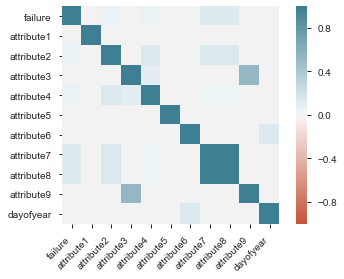

```python
#correlation among attributes with failue
corr = df.corr()
ax = sns.heatmap(
    corr,
    vmin=-1, vmax=1, center=0,
    cmap=sns.diverging_palette(20, 220, n=200),
    square=True
)
ax.set_xticklabels(
    ax.get_xticklabels(),
    rotation=45,
    horizontalalignment='right'
);
```

```python
# time difference of the data
df['pd_timestamp'] =pd.to_datetime(df['date'])
df['pd_timestamp'].max() -df['pd_timestamp'].min()
```

```
Timedelta('305 days 00:00:00')
```

```python
# get the day of the year from timestamp
df['dayofyear'] = df['pd_timestamp'].apply(lambda x: x.dayofyear)
```

```python
# number of records in different days
num_of_record = df.groupby('dayofyear')['dayofyear'].count()[0:10]
num_of_record
```

```
dayofyear
1     1163
2     1163
3     1163
4     1162
5     1161
6     1054
7      798
8      756
9      756
10     755
Name: dayofyear, dtype: int64
```

# Insights /questions to answer

- some of the devices has more records
- some of the devices has only 5/6 records
- is the failed devices send more signal?
- is the data points/ telemetry singal consistent ? getting signal in a regular basis

```python
# record per device
record_per_device = df.groupby('device')['device'].count()
record_per_device[record_per_device].sort_values(ascending=False)[0:5]
```

```
device
S1F0FP0C    304
S1F0FP0C    304
S1F0FP0C    304
S1F0FP0C    304
S1F0FP0C    304
Name: device, dtype: int64
```

```python
device_failure = df[df.failure==1].groupby('device')['device'].count()

device_failed_list =df[df.failure==1]['device']
device_failed_df = df[df['device'].isin(device_failed_list)]
print('total record for failed device:', device_failed_df.shape)
print('total record:', len(df))
print( 'failed device count:', len(device_failed_df['device'].unique()))
```

```
total record for failed device: (10713, 14)
total record: 124494
failed device count: 106
```

# Each device failed max 01 times

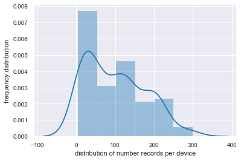

```python
# record per failed device device
record_per_failed_device = device_failed_df.groupby('device')['device'].count()
ax =sns.distplot(record_per_failed_device)

ax.set(xlabel='distribution of number records per device', ylabel='frequency distribution')
plt.show()
```

```python
# max and min records of a failed device
record_per_failed_device.sort_values(ascending=False)[0:5]
print('max number of records for failed device: ', record_per_failed_device.max())
print('min number of records for failed device: ', record_per_failed_device.min())
print('median number of records for failed device: ', record_per_failed_device.median())
```

```
max number of records for failed device:  299
min number of records for failed device:  5
median number of records for failed device:  92.0
```

```python
# max number of times a device failed count
# device_failed_df.groupby('device')['failure'].sum().sort_values(ascending=False)[0:5]
device_failed_df.groupby('device')['failure'].sum().max()
```

```
1
```

# To investigate the behavior of failed devices

- ### attribute 2, 4, 7 and 8 has correlation with failure
- original data are aggregated daily
- there are not much difference one or two days before the device failure
- min record we have is 5 days of sequence data for a failure device

# Hence, the data were aggregated again for 07 days to predict the failure probability within 07 days

```python
#list of failed devices
print(device_failed_df['device'].unique()[0:5])
```

```
['S1F023H2' 'S1F03YZM' 'S1F09DZQ' 'S1F0CTDN' 'S1F0DSTY']
```

```python
df[df.device=='S1F023H2'].tail(7)
```

|  | date | device | failure | attribute1 | attribute2 | attribute3 | attribute4 | attribute5 | attribute6 | attribute7 | attribute8 | attribute9 | pd_timestamp |
| --- | --- | --- | --- | --- | --- | --- | --- | --- | --- | --- | --- | --- | --- |
| 11443 | 2015-01-13 | S1F023H2 | 0 | 177478384 | 0 | 0 | 1 | 19 | 507971 | 16 | 16 | 3 | 2015-01-13 |
| 12198 | 2015-01-14 | S1F023H2 | 0 | 203744280 | 0 | 0 | 1 | 19 | 509250 | 16 | 16 | 3 | 2015-01-14 |
| 12914 | 2015-01-15 | S1F023H2 | 0 | 222474632 | 0 | 0 | 1 | 19 | 510519 | 16 | 16 | 3 | 2015-01-15 |
| 13629 | 2015-01-16 | S1F023H2 | 0 | 243825496 | 0 | 0 | 1 | 19 | 511783 | 16 | 16 | 3 | 2015-01-16 |
| 14344 | 2015-01-17 | S1F023H2 | 0 | 20761856 | 0 | 0 | 1 | 19 | 513110 | 16 | 16 | 3 | 2015-01-17 |
| 15059 | 2015-01-18 | S1F023H2 | 0 | 41291000 | 0 | 0 | 1 | 19 | 513722 | 16 | 16 | 3 | 2015-01-18 |
| 15773 | 2015-01-19 | S1F023H2 | 1 | 64499464 | 0 | 0 | 1 | 19 | 514661 | 16 | 16 | 3 | 2015-01-19 |

```python
df[df.device=='S1F0CTDN'].tail(7)
```

|  | date | device | failure | attribute1 | attribute2 | attribute3 | attribute4 | attribute5 | attribute6 | attribute7 | attribute8 | attribute9 | pd_timestamp |
| --- | --- | --- | --- | --- | --- | --- | --- | --- | --- | --- | --- | --- | --- |
| 63 | 2015-01-01 | S1F0CTDN | 0 | 50147888 | 528 | 0 | 4 | 9 | 381198 | 32 | 32 | 3 | 2015-01-01 |
| 1226 | 2015-01-02 | S1F0CTDN | 0 | 72104024 | 528 | 0 | 4 | 9 | 382459 | 32 | 32 | 3 | 2015-01-02 |
| 2389 | 2015-01-03 | S1F0CTDN | 0 | 91492168 | 528 | 0 | 4 | 9 | 383713 | 32 | 32 | 3 | 2015-01-03 |
| 3552 | 2015-01-04 | S1F0CTDN | 0 | 112311608 | 528 | 0 | 4 | 9 | 384948 | 32 | 32 | 3 | 2015-01-04 |
| 4713 | 2015-01-05 | S1F0CTDN | 0 | 134261688 | 528 | 0 | 4 | 9 | 386214 | 32 | 32 | 3 | 2015-01-05 |
| 5856 | 2015-01-06 | S1F0CTDN | 0 | 159974064 | 528 | 0 | 4 | 9 | 387343 | 32 | 32 | 3 | 2015-01-06 |
| 6879 | 2015-01-07 | S1F0CTDN | 1 | 184069720 | 528 | 0 | 4 | 9 | 387871 | 32 | 32 | 3 | 2015-01-07 |

```python
df[df.device=='Z1F0LVGY'].tail(7)
```

|  | date | device | failure | attribute1 | attribute2 | attribute3 | attribute4 | attribute5 | attribute6 | attribute7 | attribute8 | attribute9 | pd_timestamp |
| --- | --- | --- | --- | --- | --- | --- | --- | --- | --- | --- | --- | --- | --- |
| 23526 | 2015-01-29 | Z1F0LVGY | 0 | 115284304 | 0 | 0 | 0 | 7 | 320221 | 24 | 24 | 0 | 2015-01-29 |
| 24238 | 2015-01-30 | Z1F0LVGY | 0 | 75400928 | 0 | 0 | 0 | 7 | 320221 | 24 | 24 | 0 | 2015-01-30 |
| 24950 | 2015-01-31 | Z1F0LVGY | 0 | 26109808 | 0 | 0 | 0 | 7 | 320226 | 24 | 24 | 0 | 2015-01-31 |
| 25662 | 2015-02-01 | Z1F0LVGY | 0 | 22379624 | 0 | 0 | 0 | 7 | 320226 | 24 | 24 | 0 | 2015-02-01 |
| 26374 | 2015-02-02 | Z1F0LVGY | 0 | 222708952 | 0 | 0 | 0 | 7 | 320226 | 24 | 24 | 0 | 2015-02-02 |
| 27086 | 2015-02-03 | Z1F0LVGY | 0 | 187013784 | 0 | 0 | 0 | 7 | 320226 | 24 | 24 | 0 | 2015-02-03 |
| 27798 | 2015-02-04 | Z1F0LVGY | 1 | 184775672 | 0 | 0 | 0 | 7 | 320227 | 24 | 24 | 0 | 2015-02-04 |

```python
df[df.device=='Z1F148T1'].tail(7)
```

|  | date | device | failure | attribute1 | attribute2 | attribute3 | attribute4 | attribute5 | attribute6 | attribute7 | attribute8 | attribute9 | pd_timestamp |
| --- | --- | --- | --- | --- | --- | --- | --- | --- | --- | --- | --- | --- | --- |
| 70518 | 2015-04-14 | Z1F148T1 | 0 | 141054368 | 0 | 0 | 0 | 8 | 198466 | 96 | 96 | 0 | 2015-04-14 |
| 70922 | 2015-04-15 | Z1F148T1 | 0 | 152826840 | 0 | 0 | 0 | 8 | 198466 | 96 | 96 | 0 | 2015-04-15 |
| 71326 | 2015-04-16 | Z1F148T1 | 0 | 171971496 | 0 | 0 | 0 | 8 | 198466 | 96 | 96 | 0 | 2015-04-16 |
| 71689 | 2015-04-17 | Z1F148T1 | 0 | 183377408 | 0 | 0 | 0 | 8 | 198466 | 96 | 96 | 0 | 2015-04-17 |
| 72049 | 2015-04-18 | Z1F148T1 | 0 | 201716856 | 0 | 0 | 9 | 8 | 198466 | 80 | 80 | 0 | 2015-04-18 |
| 72409 | 2015-04-19 | Z1F148T1 | 0 | 40510240 | 0 | 0 | 9 | 8 | 198466 | 80 | 80 | 0 | 2015-04-19 |
| 72769 | 2015-04-20 | Z1F148T1 | 1 | 134062824 | 0 | 0 | 9 | 8 | 198466 | 80 | 80 | 0 | 2015-04-20 |

```python
df[df.device=='S1F01E6Y'].tail(7)
```

[output not shown]

```python
#alarm code raised by a device
alarm =df[df.device=='Z1F148T1'].groupby('attribute6')['attribute6'].count()
alarm.sort_values(ascending=False)
```

```
attribute6
198461    68
198466    24
198463     2
189955     1
183748     1
184168     1
185379     1
186541     1
187682     1
188776     1
191575     1
191120     1
192683     1
193868     1
195036     1
196117     1
197244     1
198404     1
182606     1
Name: attribute6, dtype: int64
```

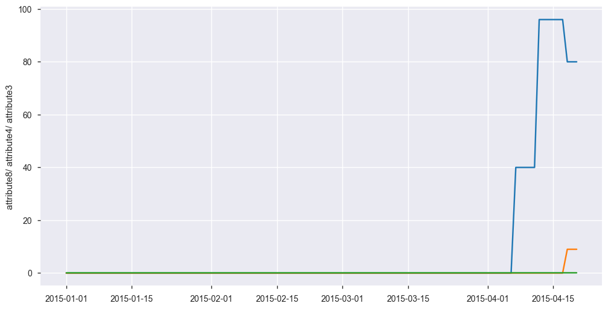

```python
# telemetry singal behavior a device goes down
plt.figure(figsize=(12, 6))
plt.plot(Z1F148T1['pd_timestamp'], Z1F148T1['attribute8'])
plt.plot(Z1F148T1['pd_timestamp'], Z1F148T1['attribute4'])
plt.plot(Z1F148T1['pd_timestamp'], Z1F148T1['attribute3'])
plt.ylabel('attribute8/ attribute4/ attribute3')
```

# Feature Engineering

- ### attribute 1, 2 and 6 seems alarm code. Hence, these attributes will be converted into one hot encoding/categorical variables.
- attribute 3,4,5,7,8 and 9 seems numeric (as there is no direct indication about the data feature name). Hence, these attributes were preprocessed as numric values.
- for failue device, the last record is the one when it failed. Hence, for each device last 07 days records were retrieved for preprocessing

```python
# to get last 07 days data, the processing is done using bigquery

query = """ select * from
 (
   select *,
   rank() over( partition by device order by DAYOFYEAR desc) failure_to_days
   FROM `data-services-asia-dev.kamal.device_failure`
 )
 where failure_to_days <=7 """

from google.cloud import bigquery
last_07_days_df = bigquery.Client().query(query).to_dataframe()
last_07_days_df.head()
```

|  | date | device | failure | attribute1 | attribute2 | attribute3 | attribute4 | attribute5 | attribute6 | attribute7 | attribute8 | attribute9 | DAYOFYEAR | failure_to_days |
| --- | --- | --- | --- | --- | --- | --- | --- | --- | --- | --- | --- | --- | --- | --- |
| 0 | 2015-01-06 | S1F01085 | 0 | 128832128 | 56 | 0 | 52 | 6 | 409404 | 0 | 0 | 7 | 6 | 1 |
| 1 | 2015-01-05 | S1F01085 | 0 | 97393448 | 56 | 0 | 52 | 6 | 408114 | 0 | 0 | 7 | 5 | 2 |
| 2 | 2015-01-04 | S1F01085 | 0 | 128073224 | 56 | 0 | 52 | 6 | 407439 | 0 | 0 | 7 | 4 | 3 |
| 3 | 2015-01-03 | S1F01085 | 0 | 124017368 | 56 | 0 | 52 | 6 | 407438 | 0 | 0 | 7 | 3 | 4 |
| 4 | 2015-01-02 | S1F01085 | 0 | 1650864 | 56 | 0 | 52 | 6 | 407438 | 0 | 0 | 7 | 2 | 5 |

# # the previous aggregation was done for each device for last 07 days.

- In this aggregation phase, we sum up the alarms if it was raised for multiple time with 07 days.

# creating pipeline

```python
def train_n_test_data(df):
    y=df[df.failure_to_days == 1]['failure']  # Labels
    training_X= df.drop(columns=['failure'],  axis=1)
    X = training_X
    return X,y

def print_fn(y_test, y_pred):
    print ('Accuracy:', accuracy_score(y_test, y_pred))
    print ('F1 score:', f1_score(y_test, y_pred))
    print ('Recall:', recall_score(y_test, y_pred))
    print ('Precision:', precision_score(y_test, y_pred))
    print ('\n clasification report:\n', classification_report(y_test, y_pred))
    print ('\n confussion matrix:\n',confusion_matrix(y_test, y_pred))
```

```python
class FeaturesSelector(BaseEstimator, TransformerMixin):
#Class Constructor
    def __init__( self, feature_names ):
        self._feature_names = feature_names

    #Return self nothing else to do here
    def fit( self, X, y = None ):
        return self

    #Method that describes what we need this transformer to do
    def transform( self, X, y = None ):
        return X[ self._feature_names ]

class NumericalFeatureTransformer( BaseEstimator, TransformerMixin ):
    #Class Constructor
    def __init__( self ):
        self.aggregation = {
        'attribute3': {
            'attribute3_avg': 'mean',
            'attribute3_max' : 'max',
            'attribute3_min' : 'min',
            'attribute3_median' : 'median'
        },
        'attribute4' : {
            'attribute4_avg': 'mean',
            'attribute4_max' : 'max',
            'attribute4_min' : 'min',
            'attribute4_median' : 'median'

        },
        'attribute5' : {
            'attribute5_avg': 'mean',
            'attribute5_max' : 'max',
            'attribute5_min' : 'min',
            'attribute5_median' : 'median'

        },
        'attribute7' : {
            'attribute7_avg': 'mean',
            'attribute7_max' : 'max',
            'attribute7_min' : 'min',
            'attribute7_median' : 'median'

        },
        'attribute8' : {
            'attribute8_avg': 'mean',
            'attribute8_max' : 'max',
            'attribute8_min' : 'min',
            'attribute8_median' : 'median'

        },
        'attribute9' : {
            'attribute9_avg': 'mean',
            'attribute9_max' : 'max',
            'attribute9_min' : 'min',
            'attribute9_median' : 'median'

            }
        }

    #Return self nothing else to do here
    def fit( self, X, y = None ):
        return self

    #Method that describes what we need this transformer to do
    def transform( self, X, y = None ):
        agg_numerical_data = X.groupby('device').agg(self.aggregation)
        agg_numerical_data.columns = agg_numerical_data.columns.droplevel()
        return agg_numerical_data


class CategoricalFeatureTransformer( BaseEstimator, TransformerMixin ):
    def __init__( self ):
#         return self
        self._name=0

        #Return self nothing else to do here
    def fit( self, X, y = None ):
        return self

    #Method that describes what we need this transformer to do
    def transform( self, X, y = None ):
        """
        get dummy variables/ one hot coding for categorical data.
        and then in this aggregation, we sum up the alarms of one hot encoded data,
        if it was raised for multiple time with 07 days
        """

        list_of_attribute = list(X)
        list_of_attribute.remove('device')
        categorical_to_dummy_df =pd.get_dummies(data=X, columns=list_of_attribute).groupby('device').sum()
        return categorical_to_dummy_df

class DimensionReduction(BaseEstimator, TransformerMixin):
    def __init__( self, n_components=7 ):
#         return self
        self.n_components=n_components

    #Return self nothing else to do here
    def fit( self, X, y = None ):
        return self

    def transform( self, X, y = None ):
        pca = PCA(self.n_components)
        PCA_X = pca.fit_transform(X)
        return PCA_X

numerical_features = ['device','attribute3','attribute4','attribute5','attribute7','attribute8', 'attribute9']
categorical_features = ['device','attribute1', 'attribute2','attribute6']

numerical_pipeline = Pipeline(steps=[
    ('feature_selector', FeaturesSelector(numerical_features)),
    ('num_feature_transform', NumericalFeatureTransformer())])

categorical_pipeline = Pipeline(steps=[
    ('feature_selector', FeaturesSelector(categorical_features)),
    ('cat_feature_transform', CategoricalFeatureTransformer())])



#using FeatureUnion
full_pipeline_FeatUnion = FeatureUnion( transformer_list = [ ( 'categorical_pipeline', categorical_pipeline ),
                                                  ( 'numerical_pipeline', numerical_pipeline ) ] )

full_pipeline = Pipeline( steps = [ ( 'Feature_union', full_pipeline_FeatUnion )
                                   , ( 'dimension_reduction', DimensionReduction(n_components=10))] )

full_pipeline_rf = Pipeline( steps = [
                                    ('rf_classifier', RandomForestClassifier(class_weight=dict({1:10, 0:1})))] )

classifiers = [
    RandomForestClassifier(class_weight=dict({1:10, 0:1})),
    XGBClassifier()

]

for classifier in classifiers:
    pipe = Pipeline( steps = [ ('classifier', classifier)] )
```

# Train & Test with default parameters

### dataset is unbalanced

- ### add higher weight to failure device ({1:10,0:1}), class weight
- ultimate goal of this model building is to predict device failure and reduce maintenance cost. So, high false positive or false negative in both cases, it will increase cost.
- Hence, it is necessary to have balance/optimize recall and precision value. In a nutshell, F1-score value needs to be maximize to reduce the maintainence cost

```python
df_X.shape
```

```
(7749, 13)
```

```python
df_X,y = train_n_test_data(last_07_days_df)
X =full_pipeline.fit_transform(df_X,y)

X_train, X_test, y_train, y_test = train_test_split(X, y, test_size=0.3) # 70% training and 30% test


for classifier in classifiers:
    print('classifier: ', classifier)
    pipe = Pipeline( steps = [ ('classifier', classifier)] )
    #fit pipeline
    pipe.fit( X_train, y_train )
    #use pipeline to predict it
    y_pred = pipe.predict( X_test )
    y_pred_proba= pipe.predict_proba( X_test )
    print('predicted probability\n', y_pred_proba[0:5])
    print('\n')
    print_fn( y_test,y_pred )
```

```
classifier:  RandomForestClassifier(bootstrap=True, class_weight={0: 1, 1: 10},
                       criterion='gini', max_depth=None, max_features='auto',
                       max_leaf_nodes=None, min_impurity_decrease=0.0,
                       min_impurity_split=None, min_samples_leaf=1,
                       min_samples_split=2, min_weight_fraction_leaf=0.0,
                       n_estimators=10, n_jobs=None, oob_score=False,
                       random_state=None, verbose=0, warm_start=False)
predicted probability
 [[0.9 0.1]
 [1.  0. ]
 [1.  0. ]
 [1.  0. ]
 [1.  0. ]]


Accuracy: 0.9116809116809117
F1 score: 0.47457627118644075
Recall: 0.4666666666666667
Precision: 0.4827586206896552

 clasification report:
               precision    recall  f1-score   support

           0       0.95      0.95      0.95       321
           1       0.48      0.47      0.47        30

    accuracy                           0.91       351
   macro avg       0.72      0.71      0.71       351
weighted avg       0.91      0.91      0.91       351


 confussion matrix:
 [[306  15]
 [ 16  14]]
classifier:  XGBClassifier(base_score=0.5, booster='gbtree', colsample_bylevel=1,
              colsample_bynode=1, colsample_bytree=1, gamma=0,
              learning_rate=0.1, max_delta_step=0, max_depth=3,
              min_child_weight=1, missing=None, n_estimators=100, n_jobs=1,
              nthread=None, objective='binary:logistic', random_state=0,
              reg_alpha=0, reg_lambda=1, scale_pos_weight=1, seed=None,
```

[output cut: 13 more lines]

```

 clasification report:
               precision    recall  f1-score   support

           0       0.96      0.97      0.97       321
           1       0.67      0.60      0.63        30

    accuracy                           0.94       351
   macro avg       0.81      0.79      0.80       351
weighted avg       0.94      0.94      0.94       351


 confussion matrix:
 [[312   9]
 [ 12  18]]
```

# RF hypermater: Bayesian Optimization

```python
df_X,y = train_n_test_data(last_07_days_df)
X =full_pipeline.fit_transform(df_X,y)
X_train, X_test, y_train, y_test = train_test_split(X, y, test_size=0.3) # 70% training and 30% test
def hyperopt_train_test(params):
    params.update({'class_weight':{1:10, 0:1}})

    clf = RandomForestClassifier(**params)
    y_pred =cross_val_predict(clf, X, y)
    f1_score_fold = f1_score(y, y_pred)
#     return cross_val_score(clf, X, y).mean()
    return f1_score_fold
space4rf = {
    'max_depth': hp.choice('max_depth', range(1,20)),
    'max_features': hp.choice('max_features', range(2,10)),
    'n_estimators': hp.choice('n_estimators', range(1,150)),
    'criterion': hp.choice('criterion', ["gini", "entropy"])
}


def f(params):
    acc = hyperopt_train_test(params)
    return {'loss': -acc, 'status': STATUS_OK}

trials = Trials()
best = fmin(f, space4rf, algo=tpe.suggest, max_evals=100, trials=trials)
print ('best:', best)
```

```
best: {'criterion': 1, 'max_depth': 3, 'max_features': 4, 'n_estimators': 60}
```

# xgboost hyperparameter: Bayesian Optimization

```python
df_X,y = train_n_test_data(last_07_days_df)
X =full_pipeline.fit_transform(df_X,y)
X_train, X_test, y_train, y_test = train_test_split(X, y, test_size=0.3) # 70% training and 30% test

param_hyperopt= {
    'learning_rate': hp.loguniform('learning_rate', np.log(0.01), np.log(1)),
    'max_depth': hp.choice('max_depth', range(5, 10)),
    'n_estimators': hp.choice('n_estimators', range(5, 100)),
    'num_leaves': hp.choice('num_leaves', range(5, 20)),
    'boosting_type': hp.choice('boosting_type', ['gbdt', 'dart']),
    'colsample_bytree': hp.uniform('colsample_by_tree', 0.6, 1.0),
    'reg_lambda': hp.uniform('reg_lambda', 0.0, 1.0),
}


def f(params):
    clf = XGBClassifier(**params)
    params.update({'random_state':6})
    score = cross_val_score(clf, X, y, cv=5).mean()
    y_pred =cross_val_predict(clf, X, y)
    f1_score_fold = f1_score(y, y_pred)

    return {'loss': -f1_score_fold, 'status': STATUS_OK}

trials = Trials()
best_param = fmin(f, param_hyperopt, algo=tpe.suggest, max_evals=50, trials=trials, rstate=np.random.RandomState(1))
print('best_param:', best_param)
```

```
best_param: {'boosting_type': 1, 'colsample_by_tree': 0.9206760293925685, 'learning_rate': 0.20525763991039211, 'max_depth': 4, 'n_estimators': 8, 'num_leaves': 7, 'reg_lambda': 0.9332674147569665}
```

# RF/xgboost fit with best parameters from bayesian optimization

- did not train it parameters from bayesian optimization as previous xgboost model is better.

```python
# best param
best_param
```

```
{'boosting_type': 1,
 'colsample_by_tree': 0.9206760293925685,
 'learning_rate': 0.20525763991039211,
 'max_depth': 4,
 'n_estimators': 8,
 'num_leaves': 7,
 'reg_lambda': 0.9332674147569665}
```